# Priority Score

# Theory

## Military triage- save as many soldiers as possible

In military triage situations, a utilitarian framework is employed to save the greatest number of wounded soliders in a mass casualty event

1. Identify patients who will survive without critical care (Green)
2. Exclude patients who obviously will not survive with critical care (Blue)
3. Rank order patients who will die without critical care by $P(ICU\space Survival)$ (Red > Yellow)
4. Treat as many patients as possible in order of $P(ICU\space Survival)$

## Problems with military triage approach in the COVID-19 Pandemic

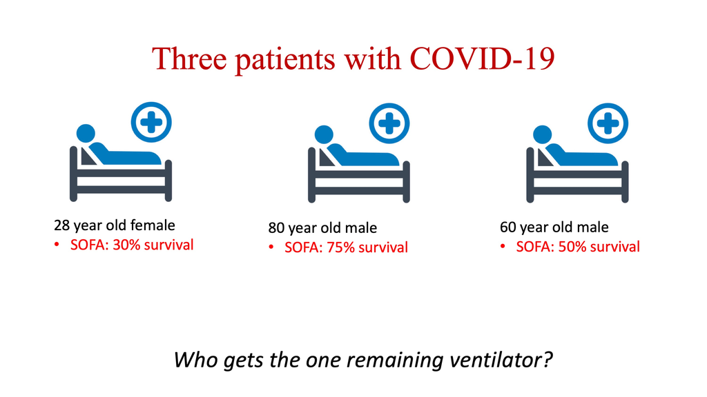

Not everyone is a young solider…$P(ICU\space Survival)$ ignores the potential life-span of the patient!

## New York ventilator allocation policy

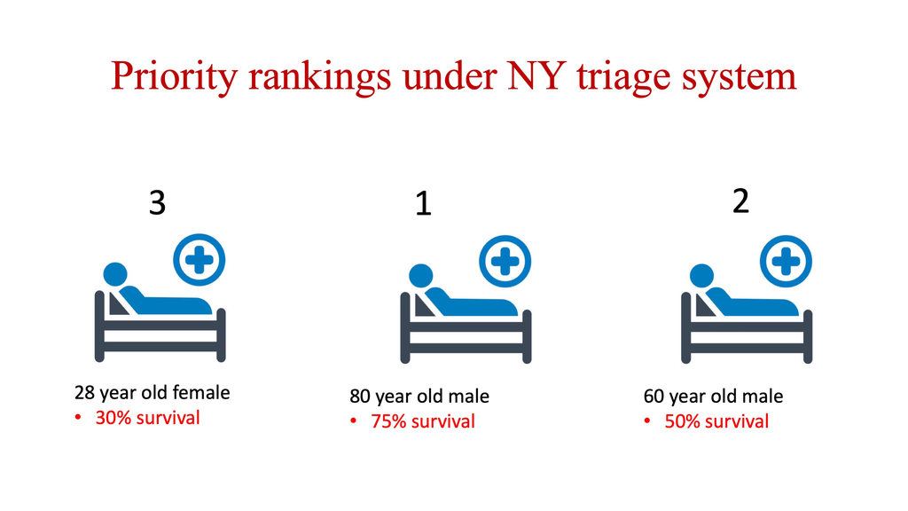

Goes against “youngest first” allocation principles.

## Maximizing life-years gained

An alternative **utilitarian** approach is to maximize life-years gained

### Priority Score that maximizes life-years gained

$$Priority \space Score = P(ICU\space Survival)*(100-age)$$